# Discretisation

Discretisation is the process of transforming continuous variables into discrete variables by creating a set of contiguous intervals that span the range of the variable's values. Discretisation is also called **binning**, where bin is an alternative name for interval.

### Discretisation helps handle outliers and may improve value spread in skewed variables

Discretisation helps handle outliers by placing these values into the lower or higher intervals, together with the remaining inlier values of the distribution. Thus, these outlier observations no longer differ from the rest of the values at the tails of the distribution, as they are now all together in the same interval / bucket. In addition, by creating appropriate bins or intervals, discretisation can help spread the values of a skewed variable across a set of bins with equal number of observations.

### Discretisation approaches

There are several approaches to transform continuous variables into discrete ones. Discretisation methods fall into 2 categories: **supervised and unsupervised**. Unsupervised methods do not use any information, other than the variable distribution, to create the contiguous bins in which the values will be placed. Supervised mwthods typically use target information in order to create the bins or intervals.

#### Unsupervised discretisation methods

- Equal width discretisation
- Equal frequency discretisation
- K-means discretisation

#### Supervised discretisation methods

- Discretisation using decision trees

## Equal width discretisation

Equal width discretisation divides the scope of possible values into N bins of the same width. The width is determined by the range of values in the variable and the number of bins we wish to use to divide the variable:

width = (max value - min value)/ N

where N is the number of bins or intervals.

For example if the values of the variable vary between 0 and 100, we create 5 bins like this: width = (100-0)/5 = 20. the bins thus are 0-20, 20-40, 40-60, 60-80, 80-100. The first and final bins (0-20 and 80-100) can be expanded to accomodate outliers (tha is, values under 0 or greater than 100 would be placed in those bins as well.)

```python
import pandas as pd
import numpy as np
import os
import matplotlib.pyplot as plt
from sklearn.model_selection import train_test_split
from sklearn.preprocessing import KBinsDiscretizer
```

```python
os.getcwd()
```

```
'/home/sahil/Dhanya_notebooks/processed_files/sec_8_discretisation'
```

```python
data = pd.read_csv('../data/titanic.csv',
                  usecols = ['age', 'fare', 'survived'])

data.head()
```

|  | survived | age | fare |
| --- | --- | --- | --- |
| 0 | 1 | 29.0000 | 211.3375 |
| 1 | 1 | 0.9167 | 151.5500 |
| 2 | 0 | 2.0000 | 151.5500 |
| 3 | 0 | 30.0000 | 151.5500 |
| 4 | 0 | 25.0000 | 151.5500 |

```python
X_train, X_test, y_train, y_test = train_test_split(
     data[['age', 'fare']],
     data['survived'],
     test_size=0.3,
     random_state=192)

X_train.shape, X_test.shape
```

```
((916, 2), (393, 2))
```

```python
X_train.fillna(X_train.mean(), inplace=True)
X_test.fillna(X_train.mean(), inplace=True)
```

```python
# First we need to determine the inetrvals' edges or limits.
# let's capture the range of the variable age

age_range = X_train['age'].max() - X_train['age'].min()

age_range
```

```
79.8333
```

```python
# let's divide the range into 8 equal width bins

age_range/8
```

```
9.9791625
```

```python
# now let's capture the lower and upper boundaries

min_value = int(np.floor(X_train['age'].min()))
max_value = int(np.ceil(X_train['age'].max()))

# let's round the bin width
inter_value = int(np.round(age_range/8))

min_value, max_value, inter_value
```

```
(0, 80, 10)
```

```python
# let's capture the interval limits, so we can pass them to the
# pandas cut function to generate the bins

intervals = [i for i in range(min_value, max_value+inter_value,
                              inter_value)]
intervals
```

```
[0, 10, 20, 30, 40, 50, 60, 70, 80]
```

```python
# let's make labels to label the different bins

labels = ['bin_' + str(i) for i in range(1, len(intervals))]

labels
```

```
['bin_1', 'bin_2', 'bin_3', 'bin_4', 'bin_5', 'bin_6', 'bin_7', 'bin_8']
```

```python
# create one column with labels
X_train['age_disc_labels'] = pd.cut(x = X_train['age'],
                                   bins=intervals,
                                   labels=labels,
                                   include_lowest=True)

# and one with bin boundaries
X_train['age_disc'] = pd.cut(x=X_train['age'],
                            bins=intervals,
                            include_lowest=True)

X_train.head()
```

|  | age | fare | age_disc_labels | age_disc |
| --- | --- | --- | --- | --- |
| 819 | 29.435223 | 7.7500 | bin_3 | (20.0, 30.0] |
| 870 | 27.000000 | 7.9250 | bin_3 | (20.0, 30.0] |
| 959 | 32.000000 | 7.9250 | bin_4 | (30.0, 40.0] |
| 185 | 42.000000 | 26.5500 | bin_5 | (40.0, 50.0] |
| 644 | 40.000000 | 31.3875 | bin_4 | (30.0, 40.0] |

When performing equal width discretisation, we gurantee that the intervals are all of the same length, however there won't necessarily be the same number of observations in each of the inetrvals.

```python
X_train.groupby('age_disc')['age'].count()
```

```
age_disc
(-0.001, 10.0]     61
(10.0, 20.0]      118
(20.0, 30.0]      449
(30.0, 40.0]      138
(40.0, 50.0]       89
(50.0, 60.0]       40
(60.0, 70.0]       17
(70.0, 80.0]        4
Name: age, dtype: int64
```

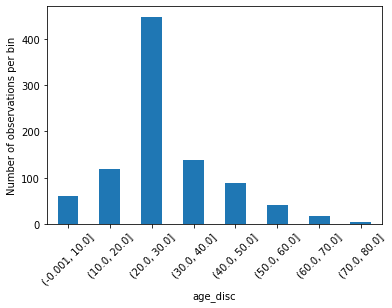

```python
X_train.groupby('age_disc')['age'].count().plot.bar()
plt.xticks(rotation=45)
plt.ylabel('Number of observations per bin')
```

Now, we can discretise Age in the test set, using the same interval boundaries that we calculated for the train set:

```python
X_test['age_disc_labels'] = pd.cut(x=X_test['age'],
                                  bins=intervals,
                                  labels=labels,
                                  include_lowest=True)

X_test['age_disc'] = pd.cut(x=X_test['age'],
                           bins=intervals,
                           include_lowest=True)

X_test.head()
```

|  | age | fare | age_disc_labels | age_disc |
| --- | --- | --- | --- | --- |
| 919 | 18.500000 | 7.2292 | bin_2 | (10.0, 20.0] |
| 197 | 19.000000 | 53.1000 | bin_2 | (10.0, 20.0] |
| 134 | 29.435223 | 89.1042 | bin_3 | (20.0, 30.0] |
| 901 | 29.435223 | 23.4500 | bin_3 | (20.0, 30.0] |
| 1029 | 29.435223 | 24.1500 | bin_3 | (20.0, 30.0] |

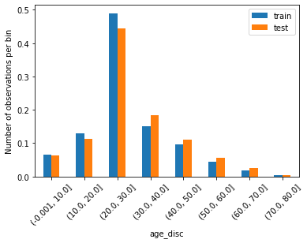

```python
t1 = X_train.groupby(['age_disc'])['age'].count() / len(X_train)
t2 = X_test.groupby(['age_disc'])['age'].count() / len(X_test)

tmp = pd.concat([t1, t2], axis=1)
tmp.columns = ['train', 'test']
tmp.plot.bar()
plt.xticks(rotation=45)
plt.ylabel('Number of observations per bin')
```